# Сборный проект «Стримчик»

Планирование кампании на 2017 год. Для этого необходимо выявить закономерности, определяющие успешность игры, определить потенциально популярный продукт и спланировать рекламные кампании.

Обработка пропусков, устранение дубликатов, изменение типов данных, удаление данных, не имеющих ценности, установка временного периода для исследования, определение времени существования платформы, вычисление предполагаемого срока появления новой успешной платформы, обозначение перспективных игровых платформх.

## Выполнение проекта

### Изучение общей информации

Импортируем библиотеки

```python
import pandas as pd
import numpy as np
import seaborn as sns
from scipy import stats as st
from IPython.display import display
import matplotlib as mpl
import matplotlib.pyplot as plt
```

Загружаем датасет и изучаем общую информацию

```python
data = pd.read_csv('/datasets/games.csv')
```

```python
data.head(20)
```

|  | Name | Platform | Year_of_Release | Genre | NA_sales | EU_sales | JP_sales | Other_sales | Critic_Score | User_Score | Rating |
| --- | --- | --- | --- | --- | --- | --- | --- | --- | --- | --- | --- |
| 0 | Wii Sports | Wii | 2006.0 | Sports | 41.36 | 28.96 | 3.77 | 8.45 | 76.0 | 8 | E |
| 1 | Super Mario Bros. | NES | 1985.0 | Platform | 29.08 | 3.58 | 6.81 | 0.77 | NaN | NaN | NaN |
| 2 | Mario Kart Wii | Wii | 2008.0 | Racing | 15.68 | 12.76 | 3.79 | 3.29 | 82.0 | 8.3 | E |
| 3 | Wii Sports Resort | Wii | 2009.0 | Sports | 15.61 | 10.93 | 3.28 | 2.95 | 80.0 | 8 | E |
| 4 | Pokemon Red/Pokemon Blue | GB | 1996.0 | Role-Playing | 11.27 | 8.89 | 10.22 | 1.00 | NaN | NaN | NaN |
| 5 | Tetris | GB | 1989.0 | Puzzle | 23.20 | 2.26 | 4.22 | 0.58 | NaN | NaN | NaN |
| 6 | New Super Mario Bros. | DS | 2006.0 | Platform | 11.28 | 9.14 | 6.50 | 2.88 | 89.0 | 8.5 | E |
| 7 | Wii Play | Wii | 2006.0 | Misc | 13.96 | 9.18 | 2.93 | 2.84 | 58.0 | 6.6 | E |
| 8 | New Super Mario Bros. Wii | Wii | 2009.0 | Platform | 14.44 | 6.94 | 4.70 | 2.24 | 87.0 | 8.4 | E |
| 9 | Duck Hunt | NES | 1984.0 | Shooter | 26.93 | 0.63 | 0.28 | 0.47 | NaN | NaN | NaN |
| 10 | Nintendogs | DS | 2005.0 | Simulation | 9.05 | 10.95 | 1.93 | 2.74 | NaN | NaN | NaN |
| 11 | Mario Kart DS | DS | 2005.0 | Racing | 9.71 | 7.47 | 4.13 | 1.90 | 91.0 | 8.6 | E |
| 12 | Pokemon Gold/Pokemon Silver | GB | 1999.0 | Role-Playing | 9.00 | 6.18 | 7.20 | 0.71 | NaN | NaN | NaN |
| 13 | Wii Fit | Wii | 2007.0 | Sports | 8.92 | 8.03 | 3.60 | 2.15 | 80.0 | 7.7 | E |
| 14 | Kinect Adventures! | X360 | 2010.0 | Misc | 15.00 | 4.89 | 0.24 | 1.69 | 61.0 | 6.3 | E |
| 15 | Wii Fit Plus | Wii | 2009.0 | Sports | 9.01 | 8.49 | 2.53 | 1.77 | 80.0 | 7.4 | E |
| 16 | Grand Theft Auto V | PS3 | 2013.0 | Action | 7.02 | 9.09 | 0.98 | 3.96 | 97.0 | 8.2 | M |
| 17 | Grand Theft Auto: San Andreas | PS2 | 2004.0 | Action | 9.43 | 0.40 | 0.41 | 10.57 | 95.0 | 9 | M |
| 18 | Super Mario World | SNES | 1990.0 | Platform | 12.78 | 3.75 | 3.54 | 0.55 | NaN | NaN | NaN |
| 19 | Brain Age: Train Your Brain in Minutes a Day | DS | 2005.0 | Misc | 4.74 | 9.20 | 4.16 | 2.04 | 77.0 | 7.9 | E |

```python
data.info()
```

```
<class 'pandas.core.frame.DataFrame'>
RangeIndex: 16715 entries, 0 to 16714
Data columns (total 11 columns):
 #   Column           Non-Null Count  Dtype
---  ------           --------------  -----
 0   Name             16713 non-null  object
 1   Platform         16715 non-null  object
 2   Year_of_Release  16446 non-null  float64
 3   Genre            16713 non-null  object
 4   NA_sales         16715 non-null  float64
 5   EU_sales         16715 non-null  float64
 6   JP_sales         16715 non-null  float64
 7   Other_sales      16715 non-null  float64
 8   Critic_Score     8137 non-null   float64
 9   User_Score       10014 non-null  object
 10  Rating           9949 non-null   object
dtypes: float64(6), object(5)
memory usage: 1.4+ MB
```

### Подготовка данных

Проверяем на явные дубликаты

```python
data.duplicated().sum()
```

```
0
```

Mеняем названия столбцов

```python
columns_old = data.columns
columns_new = columns_old.str.lower()
columns_df = pd.DataFrame({'old':columns_old, 'new':columns_new})
columns_dict = columns_df.set_index('old')['new'].to_dict()
data = data.rename(columns=columns_dict)
```

Проверяем результат

```python
data.head()
```

|  | name | platform | year_of_release | genre | na_sales | eu_sales | jp_sales | other_sales | critic_score | user_score | rating |
| --- | --- | --- | --- | --- | --- | --- | --- | --- | --- | --- | --- |
| 0 | Wii Sports | Wii | 2006.0 | Sports | 41.36 | 28.96 | 3.77 | 8.45 | 76.0 | 8 | E |
| 1 | Super Mario Bros. | NES | 1985.0 | Platform | 29.08 | 3.58 | 6.81 | 0.77 | NaN | NaN | NaN |
| 2 | Mario Kart Wii | Wii | 2008.0 | Racing | 15.68 | 12.76 | 3.79 | 3.29 | 82.0 | 8.3 | E |
| 3 | Wii Sports Resort | Wii | 2009.0 | Sports | 15.61 | 10.93 | 3.28 | 2.95 | 80.0 | 8 | E |
| 4 | Pokemon Red/Pokemon Blue | GB | 1996.0 | Role-Playing | 11.27 | 8.89 | 10.22 | 1.00 | NaN | NaN | NaN |

Смотрим кол-во пропусков по столбцам

```python
for i in data:
    if len(data[data[i].isna()]) != 0:
        print(i, '-', len(data[data[i].isna()])) # выводим только пропуски
```

```
name - 2
year_of_release - 269
genre - 2
critic_score - 8578
user_score - 6701
rating - 6766
```

Возможные причины пропусков:  
name - ошибка при сборе данных  
year_of_release - ошибка при вводе данных  
genre - ошибка при вводе данных  
critic_score - не проводилась оценка / ошибка при сборе данных  
user_score - не проводилась оценка / ошибка при сборе данных  
rating - не проводилась оценка (игра вышла до организации рейтинга или изначально выпускалась не для рынка Северной Америки) / ошибка при сборе данных

Заполняем пропуски в рейтинге на NDA (no data available)

```python
data['rating'] = data['rating'].fillna('NDA')
#data['rating'].unique()
```

Убираем пропуски в годах выпуска

```python
data['year_of_release'].unique()
```

```
array([2006., 1985., 2008., 2009., 1996., 1989., 1984., 2005., 1999.,
       2007., 2010., 2013., 2004., 1990., 1988., 2002., 2001., 2011.,
       1998., 2015., 2012., 2014., 1992., 1997., 1993., 1994., 1982.,
       2016., 2003., 1986., 2000.,   nan, 1995., 1991., 1981., 1987.,
       1980., 1983.])
```

```python
data = data.dropna(subset=['year_of_release'])
```

```python
data['year_of_release'].unique()
```

```
array([2006., 1985., 2008., 2009., 1996., 1989., 1984., 2005., 1999.,
       2007., 2010., 2013., 2004., 1990., 1988., 2002., 2001., 2011.,
       1998., 2015., 2012., 2014., 1992., 1997., 1993., 1994., 1982.,
       2016., 2003., 1986., 2000., 1995., 1991., 1981., 1987., 1980.,
       1983.])
```

Необходимо изменить тип данных в столбце 'Year_of_Release'  
Данные в 'User_Score', скорее всего, д.б. float64

Меняем тип данных в годе выпуска

```python
data['year_of_release'] = data['year_of_release'].astype('int')
```

Смотрим пропуски в названии

```python
display(data.loc[(data['name']).isna()])
```

|  | name | platform | year_of_release | genre | na_sales | eu_sales | jp_sales | other_sales | critic_score | user_score | rating |
| --- | --- | --- | --- | --- | --- | --- | --- | --- | --- | --- | --- |
| 659 | NaN | GEN | 1993 | NaN | 1.78 | 0.53 | 0.00 | 0.08 | NaN | NaN | NDA |
| 14244 | NaN | GEN | 1993 | NaN | 0.00 | 0.00 | 0.03 | 0.00 | NaN | NaN | NDA |

Удаляем строки с пропусками в названии из-за незначительности данных

```python
data = data.dropna(subset=['name'])
```

Убираем пропуски в оценке критиков

```python
data['critic_score'].unique()
```

```
array([76., nan, 82., 80., 89., 58., 87., 91., 61., 97., 95., 77., 88.,
       83., 94., 93., 85., 86., 98., 96., 90., 84., 73., 74., 78., 92.,
       71., 72., 68., 62., 49., 67., 81., 66., 56., 79., 70., 59., 64.,
       75., 60., 63., 69., 50., 25., 42., 44., 55., 48., 57., 29., 47.,
       65., 54., 20., 53., 37., 38., 33., 52., 30., 32., 43., 45., 51.,
       40., 46., 39., 34., 41., 36., 31., 27., 35., 26., 19., 28., 23.,
       24., 21., 17., 13.])
```

```python
# всесто пропусков ставим отрицательное значение
data['critic_score'] = data['critic_score'].fillna(-1)
```

```python
data['critic_score'].unique()
```

```
array([76., -1., 82., 80., 89., 58., 87., 91., 61., 97., 95., 77., 88.,
       83., 94., 93., 85., 86., 98., 96., 90., 84., 73., 74., 78., 92.,
       71., 72., 68., 62., 49., 67., 81., 66., 56., 79., 70., 59., 64.,
       75., 60., 63., 69., 50., 25., 42., 44., 55., 48., 57., 29., 47.,
       65., 54., 20., 53., 37., 38., 33., 52., 30., 32., 43., 45., 51.,
       40., 46., 39., 34., 41., 36., 31., 27., 35., 26., 19., 28., 23.,
       24., 21., 17., 13.])
```

```python
data['user_score'].unique()
```

```
array(['8', nan, '8.3', '8.5', '6.6', '8.4', '8.6', '7.7', '6.3', '7.4',
       '8.2', '9', '7.9', '8.1', '8.7', '7.1', '3.4', '5.3', '4.8', '3.2',
       '8.9', '6.4', '7.8', '7.5', '2.6', '7.2', '9.2', '7', '7.3', '4.3',
       '7.6', '5.7', '5', '9.1', '6.5', 'tbd', '8.8', '6.9', '9.4', '6.8',
       '6.1', '6.7', '5.4', '4', '4.9', '4.5', '9.3', '6.2', '4.2', '6',
       '3.7', '4.1', '5.8', '5.6', '5.5', '4.4', '4.6', '5.9', '3.9',
       '3.1', '2.9', '5.2', '3.3', '4.7', '5.1', '3.5', '2.5', '1.9', '3',
       '2.7', '2.2', '2', '9.5', '2.1', '3.6', '2.8', '1.8', '3.8', '0',
       '1.6', '9.6', '2.4', '1.7', '1.1', '0.3', '1.5', '0.7', '1.2',
       '2.3', '0.5', '1.3', '0.2', '0.6', '1.4', '0.9', '1', '9.7'],
      dtype=object)
```

```python
# вместо пропусков ставим отрицательное значение
data['user_score'] = data['user_score'].fillna(-1)
```

```python
data['user_score'].unique()
```

```
array(['8', -1, '8.3', '8.5', '6.6', '8.4', '8.6', '7.7', '6.3', '7.4',
       '8.2', '9', '7.9', '8.1', '8.7', '7.1', '3.4', '5.3', '4.8', '3.2',
       '8.9', '6.4', '7.8', '7.5', '2.6', '7.2', '9.2', '7', '7.3', '4.3',
       '7.6', '5.7', '5', '9.1', '6.5', 'tbd', '8.8', '6.9', '9.4', '6.8',
       '6.1', '6.7', '5.4', '4', '4.9', '4.5', '9.3', '6.2', '4.2', '6',
       '3.7', '4.1', '5.8', '5.6', '5.5', '4.4', '4.6', '5.9', '3.9',
       '3.1', '2.9', '5.2', '3.3', '4.7', '5.1', '3.5', '2.5', '1.9', '3',
       '2.7', '2.2', '2', '9.5', '2.1', '3.6', '2.8', '1.8', '3.8', '0',
       '1.6', '9.6', '2.4', '1.7', '1.1', '0.3', '1.5', '0.7', '1.2',
       '2.3', '0.5', '1.3', '0.2', '0.6', '1.4', '0.9', '1', '9.7'],
      dtype=object)
```

Считаем общие продажи

```python
data['total_sales'] = data[['na_sales','eu_sales','jp_sales', 'other_sales']].sum(axis = 1)
```

Изучаем оценку 'tbd'

```python
print(data['rating'].unique())
```

```
['E' 'NDA' 'M' 'T' 'E10+' 'K-A' 'AO' 'EC' 'RP']
```

```python
print(data.loc[data['user_score'] == 'tbd', 'rating'].unique())
```

```
['E' 'E10+' 'T' 'NDA' 'M' 'EC']
```

```python
data_user_score_tbd = data.loc[data['user_score'] == 'tbd']
display(data_user_score_tbd)
data_user_score_tbd.sort_values(by='total_sales', ascending=False).groupby('rating').count()
```

|  | name | platform | year_of_release | genre | na_sales | eu_sales | jp_sales | other_sales | critic_score | user_score | rating | total_sales |
| --- | --- | --- | --- | --- | --- | --- | --- | --- | --- | --- | --- | --- |
| 119 | Zumba Fitness | Wii | 2010 | Sports | 3.45 | 2.59 | 0.0 | 0.66 | -1.0 | tbd | E | 6.70 |
| 301 | Namco Museum: 50th Anniversary | PS2 | 2005 | Misc | 2.08 | 1.35 | 0.0 | 0.54 | 61.0 | tbd | E10+ | 3.97 |
| 520 | Zumba Fitness 2 | Wii | 2011 | Sports | 1.51 | 1.03 | 0.0 | 0.27 | -1.0 | tbd | T | 2.81 |
| 645 | uDraw Studio | Wii | 2010 | Misc | 1.65 | 0.57 | 0.0 | 0.20 | 71.0 | tbd | E | 2.42 |
| 718 | Just Dance Kids | Wii | 2010 | Misc | 1.52 | 0.54 | 0.0 | 0.18 | -1.0 | tbd | E | 2.24 |
| ... | ... | ... | ... | ... | ... | ... | ... | ... | ... | ... | ... | ... |
| 16695 | Planet Monsters | GBA | 2001 | Action | 0.01 | 0.00 | 0.0 | 0.00 | 67.0 | tbd | E | 0.01 |
| 16697 | Bust-A-Move 3000 | GC | 2003 | Puzzle | 0.01 | 0.00 | 0.0 | 0.00 | 53.0 | tbd | E | 0.01 |
| 16698 | Mega Brain Boost | DS | 2008 | Puzzle | 0.01 | 0.00 | 0.0 | 0.00 | 48.0 | tbd | E | 0.01 |
| 16704 | Plushees | DS | 2008 | Simulation | 0.01 | 0.00 | 0.0 | 0.00 | -1.0 | tbd | E | 0.01 |
| 16706 | Men in Black II: Alien Escape | GC | 2003 | Shooter | 0.01 | 0.00 | 0.0 | 0.00 | -1.0 | tbd | T | 0.01 |

2376 rows × 12 columns

| rating | name | platform | year_of_release | genre | na_sales | eu_sales | jp_sales | other_sales | critic_score | user_score | total_sales |
| --- | --- | --- | --- | --- | --- | --- | --- | --- | --- | --- | --- |
| E | 1548 | 1548 | 1548 | 1548 | 1548 | 1548 | 1548 | 1548 | 1548 | 1548 | 1548 |
| E10+ | 360 | 360 | 360 | 360 | 360 | 360 | 360 | 360 | 360 | 360 | 360 |
| EC | 7 | 7 | 7 | 7 | 7 | 7 | 7 | 7 | 7 | 7 | 7 |
| M | 42 | 42 | 42 | 42 | 42 | 42 | 42 | 42 | 42 | 42 | 42 |
| NDA | 50 | 50 | 50 | 50 | 50 | 50 | 50 | 50 | 50 | 50 | 50 |
| T | 369 | 369 | 369 | 369 | 369 | 369 | 369 | 369 | 369 | 369 | 369 |

```python
print(data_user_score_tbd['total_sales'].sum() / data['total_sales'].sum() * 100)
```

```
5.065024499765724
```

Такое ощущение, что эти игры не продавались, а были розданы для тестирования.

Вместо 'tbd' в user_score ставим -1

```python
data.loc[(data['user_score'] == 'tbd'), 'user_score'] = -1
```

```python
data['user_score'].unique()
```

```
array(['8', -1, '8.3', '8.5', '6.6', '8.4', '8.6', '7.7', '6.3', '7.4',
       '8.2', '9', '7.9', '8.1', '8.7', '7.1', '3.4', '5.3', '4.8', '3.2',
       '8.9', '6.4', '7.8', '7.5', '2.6', '7.2', '9.2', '7', '7.3', '4.3',
       '7.6', '5.7', '5', '9.1', '6.5', '8.8', '6.9', '9.4', '6.8', '6.1',
       '6.7', '5.4', '4', '4.9', '4.5', '9.3', '6.2', '4.2', '6', '3.7',
       '4.1', '5.8', '5.6', '5.5', '4.4', '4.6', '5.9', '3.9', '3.1',
       '2.9', '5.2', '3.3', '4.7', '5.1', '3.5', '2.5', '1.9', '3', '2.7',
       '2.2', '2', '9.5', '2.1', '3.6', '2.8', '1.8', '3.8', '0', '1.6',
       '9.6', '2.4', '1.7', '1.1', '0.3', '1.5', '0.7', '1.2', '2.3',
       '0.5', '1.3', '0.2', '0.6', '1.4', '0.9', '1', '9.7'], dtype=object)
```

Меняем тип данных в столбце оценок пользователей для удобства дальнейших подсчётов

```python
data['user_score'] = pd.to_numeric(data['user_score'])
```

```python
data.info()
```

```
<class 'pandas.core.frame.DataFrame'>
Int64Index: 16444 entries, 0 to 16714
Data columns (total 12 columns):
 #   Column           Non-Null Count  Dtype
---  ------           --------------  -----
 0   name             16444 non-null  object
 1   platform         16444 non-null  object
 2   year_of_release  16444 non-null  int64
 3   genre            16444 non-null  object
 4   na_sales         16444 non-null  float64
 5   eu_sales         16444 non-null  float64
 6   jp_sales         16444 non-null  float64
 7   other_sales      16444 non-null  float64
 8   critic_score     16444 non-null  float64
 9   user_score       16444 non-null  float64
 10  rating           16444 non-null  object
 11  total_sales      16444 non-null  float64
dtypes: float64(7), int64(1), object(4)
memory usage: 1.6+ MB
```

```python
# Комментарий ревьюера 0
# Посмотрим, что у нас осталось
temp = data.copy()
list_c = ['name', 'platform', 'year_of_release', 'genre', 'critic_score', 'user_score', 'rating']
print(temp.info())
for col_l in list_c:
  print('-'* 25)
  print(col_l, temp[col_l].sort_values().unique())
  print(col_l,': кол-во NaN',temp[col_l].isna().sum(),
        ', процент NaN', round(temp[col_l].isna().sum()/len(temp)*100, 2),'%')
```

```
<class 'pandas.core.frame.DataFrame'>
Int64Index: 16444 entries, 0 to 16714
Data columns (total 12 columns):
 #   Column           Non-Null Count  Dtype
---  ------           --------------  -----
 0   name             16444 non-null  object
 1   platform         16444 non-null  object
 2   year_of_release  16444 non-null  int64
 3   genre            16444 non-null  object
 4   na_sales         16444 non-null  float64
 5   eu_sales         16444 non-null  float64
 6   jp_sales         16444 non-null  float64
 7   other_sales      16444 non-null  float64
 8   critic_score     16444 non-null  float64
 9   user_score       16444 non-null  float64
 10  rating           16444 non-null  object
 11  total_sales      16444 non-null  float64
dtypes: float64(7), int64(1), object(4)
memory usage: 1.6+ MB
None
-------------------------
name [' Beyblade Burst' ' Fire Emblem Fates' " Frozen: Olaf's Quest" ...
 'uDraw Studio' 'uDraw Studio: Instant Artist'
 '¡Shin Chan Flipa en colores!']
name : кол-во NaN 0 , процент NaN 0.0 %
-------------------------
platform ['2600' '3DO' '3DS' 'DC' 'DS' 'GB' 'GBA' 'GC' 'GEN' 'GG' 'N64' 'NES' 'NG'
 'PC' 'PCFX' 'PS' 'PS2' 'PS3' 'PS4' 'PSP' 'PSV' 'SAT' 'SCD' 'SNES' 'TG16'
 'WS' 'Wii' 'WiiU' 'X360' 'XB' 'XOne']
platform : кол-во NaN 0 , процент NaN 0.0 %
-------------------------
year_of_release [1980 1981 1982 1983 1984 1985 1986 1987 1988 1989 1990 1991 1992 1993
 1994 1995 1996 1997 1998 1999 2000 2001 2002 2003 2004 2005 2006 2007
 2008 2009 2010 2011 2012 2013 2014 2015 2016]
year_of_release : кол-во NaN 0 , процент NaN 0.0 %
-------------------------
genre ['Action' 'Adventure' 'Fighting' 'Misc' 'Platform' 'Puzzle' 'Racing'
 'Role-Playing' 'Shooter' 'Simulation' 'Sports' 'Strategy']
genre : кол-во NaN 0 , процент NaN 0.0 %
-------------------------
critic_score [-1. 13. 17. 19. 20. 21. 23. 24. 25. 26. 27. 28. 29. 30. 31. 32. 33. 34.
 35. 36. 37. 38. 39. 40. 41. 42. 43. 44. 45. 46. 47. 48. 49. 50. 51. 52.
 53. 54. 55. 56. 57. 58. 59. 60. 61. 62. 63. 64. 65. 66. 67. 68. 69. 70.
 71. 72. 73. 74. 75. 76. 77. 78. 79. 80. 81. 82. 83. 84. 85. 86. 87. 88.
 89. 90. 91. 92. 93. 94. 95. 96. 97. 98.]
critic_score : кол-во NaN 0 , процент NaN 0.0 %
-------------------------
user_score [-1.   0.   0.2  0.3  0.5  0.6  0.7  0.9  1.   1.1  1.2  1.3  1.4  1.5
  1.6  1.7  1.8  1.9  2.   2.1  2.2  2.3  2.4  2.5  2.6  2.7  2.8  2.9
  3.   3.1  3.2  3.3  3.4  3.5  3.6  3.7  3.8  3.9  4.   4.1  4.2  4.3
  4.4  4.5  4.6  4.7  4.8  4.9  5.   5.1  5.2  5.3  5.4  5.5  5.6  5.7
  5.8  5.9  6.   6.1  6.2  6.3  6.4  6.5  6.6  6.7  6.8  6.9  7.   7.1
  7.2  7.3  7.4  7.5  7.6  7.7  7.8  7.9  8.   8.1  8.2  8.3  8.4  8.5
  8.6  8.7  8.8  8.9  9.   9.1  9.2  9.3  9.4  9.5  9.6  9.7]
user_score : кол-во NaN 0 , процент NaN 0.0 %
-------------------------
rating ['AO' 'E' 'E10+' 'EC' 'K-A' 'M' 'NDA' 'RP' 'T']
rating : кол-во NaN 0 , процент NaN 0.0 %
```

### Исследовательский анализ данных

#### Количество игр, выпускавшихся в разные годы

data.groupby('year_of_release')['name'].nunique()

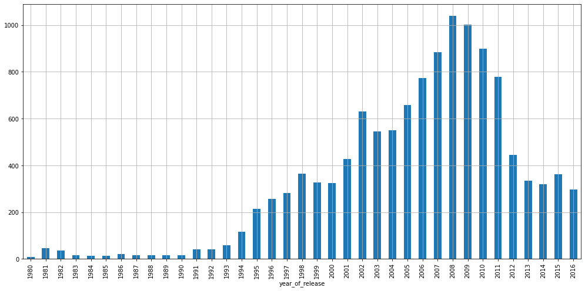

```python
data.groupby('year_of_release')['name'].nunique().plot(kind='bar', figsize=(17, 8), grid=True);
```

Данные до 2000 года можно отбросить по двум соображениям: 2008 - пик и до 2106 - 8 лет и до 2000; с 2000 до 2008 - рост, с 2008 по 2016 - пропорциональный спад.

#### Продажи игр в разрезе платформ

```python
last_year = []
first_year = []
years_live = []
median_rating = []
mean_rating = []
total_sales = []
games = []
platform = data['platform'].unique()
for i in platform:
    last_year.append(data.loc[(data['platform'] == i), 'year_of_release'].max())
    first_year.append(data.loc[(data['platform'] == i), 'year_of_release'].min())
    years_live.append((data.loc[(data['platform'] == i), 'year_of_release'].max()) - \
                      (data.loc[(data['platform'] == i), 'year_of_release'].min()))
    mean_rating.append((data.loc[(data['platform'] == i), 'critic_score'].median() + \
                        data.loc[(data['platform'] == i), 'user_score'].median() * 10) / 2)
    median_rating.append(data.loc[(data['platform'] == i), 'critic_score'].median())
    total_sales.append(data.loc[(data['platform'] == i), 'total_sales'].sum())
    games.append(data.loc[(data['platform'] == i), 'name'].count())
platforms = pd.DataFrame({'platform':platform, 'first_year':first_year, 'last_year':last_year, 'years_live':years_live, \
                          'mean_rating':mean_rating, 'median_rating':median_rating, 'games':games, 'total_sales':total_sales})
```

```python
display(platforms.sort_values(by='last_year'))
```

|  | platform | first_year | last_year | years_live | mean_rating | median_rating | games | total_sales |
| --- | --- | --- | --- | --- | --- | --- | --- | --- |
| 15 | 2600 | 1980 | 1989 | 9 | -5.50 | -1.0 | 116 | 86.48 |
| 29 | GG | 1992 | 1992 | 0 | -5.50 | -1.0 | 1 | 0.04 |
| 1 | NES | 1983 | 1994 | 11 | -5.50 | -1.0 | 98 | 251.05 |
| 24 | SCD | 1993 | 1994 | 1 | -5.50 | -1.0 | 6 | 1.86 |
| 20 | GEN | 1990 | 1994 | 4 | -5.50 | -1.0 | 27 | 28.35 |
| 28 | 3DO | 1994 | 1995 | 1 | -5.50 | -1.0 | 3 | 0.10 |
| 27 | TG16 | 1995 | 1995 | 0 | -5.50 | -1.0 | 2 | 0.16 |
| 26 | NG | 1993 | 1996 | 3 | -5.50 | -1.0 | 12 | 1.44 |
| 30 | PCFX | 1996 | 1996 | 0 | -5.50 | -1.0 | 1 | 0.03 |
| 7 | SNES | 1990 | 1999 | 9 | -5.50 | -1.0 | 239 | 200.04 |
| 23 | SAT | 1994 | 1999 | 5 | -5.50 | -1.0 | 173 | 33.59 |
| 2 | GB | 1988 | 2001 | 13 | -5.50 | -1.0 | 97 | 254.43 |
| 25 | WS | 1999 | 2001 | 2 | -5.50 | -1.0 | 6 | 1.42 |
| 11 | N64 | 1996 | 2002 | 6 | -5.50 | -1.0 | 316 | 218.01 |
| 12 | PS | 1994 | 2003 | 9 | -5.50 | -1.0 | 1190 | 727.58 |
| 19 | GC | 2001 | 2007 | 6 | 68.00 | 66.0 | 542 | 196.73 |
| 8 | GBA | 2000 | 2007 | 7 | 17.00 | 44.0 | 811 | 312.88 |
| 13 | XB | 2000 | 2008 | 8 | 71.00 | 69.0 | 803 | 251.57 |
| 21 | DC | 1998 | 2008 | 10 | -5.50 | -1.0 | 52 | 15.95 |
| 6 | PS2 | 2000 | 2011 | 11 | 59.00 | 56.0 | 2127 | 1233.56 |
| 3 | DS | 1985 | 2013 | 28 | -5.50 | -1.0 | 2121 | 802.78 |
| 16 | PSP | 2004 | 2015 | 11 | -5.50 | -1.0 | 1193 | 289.53 |
| 4 | X360 | 2005 | 2016 | 11 | 63.00 | 62.0 | 1232 | 961.24 |
| 5 | PS3 | 2006 | 2016 | 10 | 59.00 | 58.0 | 1306 | 931.34 |
| 9 | PS4 | 2013 | 2016 | 3 | 62.75 | 64.5 | 392 | 314.14 |
| 18 | WiiU | 2012 | 2016 | 4 | 60.50 | 58.0 | 147 | 82.19 |
| 17 | XOne | 2013 | 2016 | 3 | 63.50 | 67.0 | 247 | 159.32 |
| 14 | PC | 1985 | 2016 | 31 | 70.50 | 72.0 | 957 | 255.76 |
| 10 | 3DS | 2011 | 2016 | 5 | -5.50 | -1.0 | 512 | 257.81 |
| 22 | PSV | 2011 | 2016 | 5 | -5.50 | -1.0 | 429 | 53.81 |
| 0 | Wii | 2006 | 2016 | 10 | -5.50 | -1.0 | 1286 | 891.18 |

"Нормальная" продолжительность "жизни" платформы около 10 лет, исключение - 'PC, но в ней содержится несколько поколений (как минимум - 3).  
Перспективные: PS4, WiiU, XOne, 3DS и РС (для РС всегда будут игры), остальные - "на излёте", PSV - вообще, тупиковая ветвь.

#### ТОП-10 платформ с наибольшим количеством продаж

Построим для них графики.

|  | platform | first_year | last_year | years_live | mean_rating | median_rating | games | total_sales |
| --- | --- | --- | --- | --- | --- | --- | --- | --- |
| 6 | PS2 | 2000 | 2011 | 11 | 59.00 | 56.0 | 2127 | 1233.56 |
| 4 | X360 | 2005 | 2016 | 11 | 63.00 | 62.0 | 1232 | 961.24 |
| 5 | PS3 | 2006 | 2016 | 10 | 59.00 | 58.0 | 1306 | 931.34 |
| 0 | Wii | 2006 | 2016 | 10 | -5.50 | -1.0 | 1286 | 891.18 |
| 3 | DS | 1985 | 2013 | 28 | -5.50 | -1.0 | 2121 | 802.78 |
| 12 | PS | 1994 | 2003 | 9 | -5.50 | -1.0 | 1190 | 727.58 |
| 9 | PS4 | 2013 | 2016 | 3 | 62.75 | 64.5 | 392 | 314.14 |
| 8 | GBA | 2000 | 2007 | 7 | 17.00 | 44.0 | 811 | 312.88 |
| 16 | PSP | 2004 | 2015 | 11 | -5.50 | -1.0 | 1193 | 289.53 |
| 10 | 3DS | 2011 | 2016 | 5 | -5.50 | -1.0 | 512 | 257.81 |

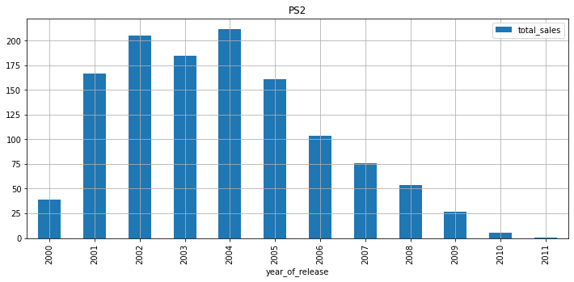

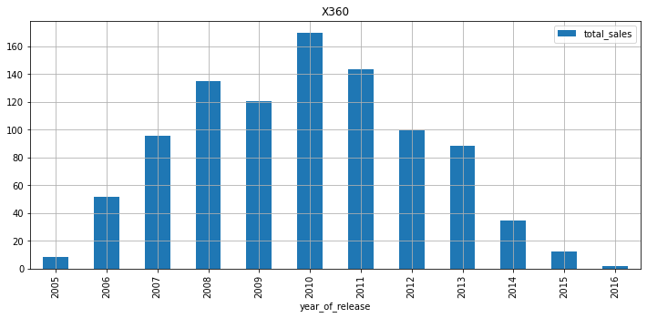

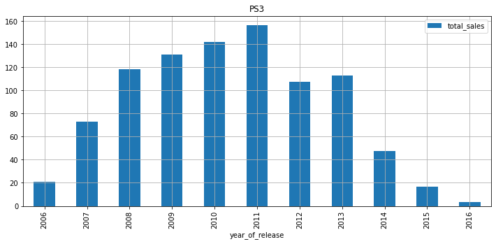

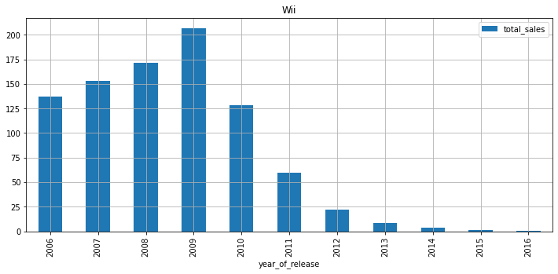

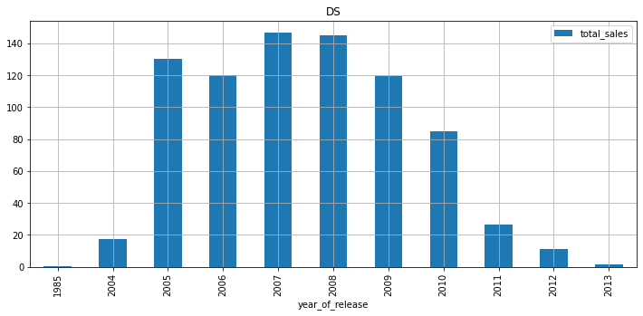

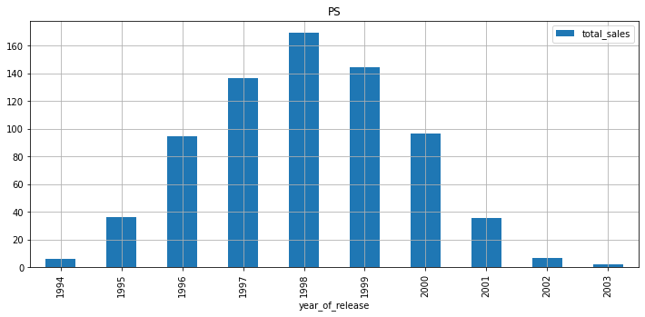

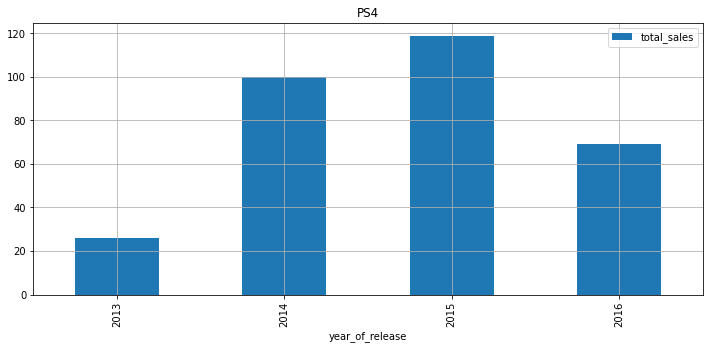

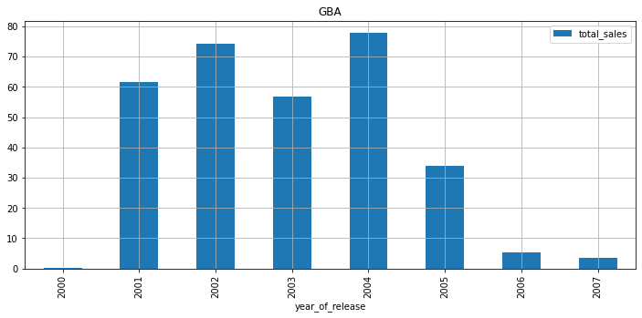

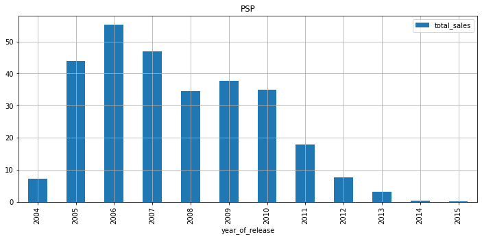

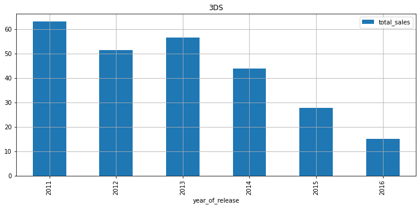

```python
platform_top = platforms.sort_values(by='total_sales',ascending=False).head(10)
display(platform_top)
platform_top_name = platform_top['platform'].reset_index(drop=True)
platform_year_unique = []
platform_top_data = []
platform_top_data = data.query('platform in @platform_top_name') #year_of_release > 2004 and
platform_top_data_cut = platform_top_data[['platform', 'year_of_release', 'total_sales']].sort_values(by='year_of_release')
#top_platform_data = platform_top_data_cut
#display(platform_top_data_cut)
for i in platform_top_name:
    platform_top_data_cut.query('platform in @i').\
    pivot_table(index='year_of_release', values='total_sales', aggfunc='sum').\
    plot(kind='bar', title=i, grid=True, figsize=(12, 5));
```

Наибольшее количество игр для платформы выпускается или в начале жизненнгого цикла или достигает пика к его середине, затем - спад.

Введём синтетический "коэффициент успешности", отражающий отношение поданных копий к количеству игр для платформы.

Ознакомимся с данными в разрезе этого коэффициента

```python
platforms['success_rate'] = platforms['total_sales'] / platforms['games']
display(platforms.query('total_sales > 90 or last_year > 2008').sort_values(by='first_year'))
```

|  | platform | first_year | last_year | years_live | mean_rating | median_rating | games | total_sales | success_rate |
| --- | --- | --- | --- | --- | --- | --- | --- | --- | --- |
| 1 | NES | 1983 | 1994 | 11 | -5.50 | -1.0 | 98 | 251.05 | 2.561735 |
| 3 | DS | 1985 | 2013 | 28 | -5.50 | -1.0 | 2121 | 802.78 | 0.378491 |
| 14 | PC | 1985 | 2016 | 31 | 70.50 | 72.0 | 957 | 255.76 | 0.267252 |
| 2 | GB | 1988 | 2001 | 13 | -5.50 | -1.0 | 97 | 254.43 | 2.622990 |
| 7 | SNES | 1990 | 1999 | 9 | -5.50 | -1.0 | 239 | 200.04 | 0.836987 |
| 12 | PS | 1994 | 2003 | 9 | -5.50 | -1.0 | 1190 | 727.58 | 0.611412 |
| 11 | N64 | 1996 | 2002 | 6 | -5.50 | -1.0 | 316 | 218.01 | 0.689905 |
| 6 | PS2 | 2000 | 2011 | 11 | 59.00 | 56.0 | 2127 | 1233.56 | 0.579953 |
| 8 | GBA | 2000 | 2007 | 7 | 17.00 | 44.0 | 811 | 312.88 | 0.385795 |
| 13 | XB | 2000 | 2008 | 8 | 71.00 | 69.0 | 803 | 251.57 | 0.313288 |
| 19 | GC | 2001 | 2007 | 6 | 68.00 | 66.0 | 542 | 196.73 | 0.362970 |
| 16 | PSP | 2004 | 2015 | 11 | -5.50 | -1.0 | 1193 | 289.53 | 0.242691 |
| 4 | X360 | 2005 | 2016 | 11 | 63.00 | 62.0 | 1232 | 961.24 | 0.780227 |
| 0 | Wii | 2006 | 2016 | 10 | -5.50 | -1.0 | 1286 | 891.18 | 0.692986 |
| 5 | PS3 | 2006 | 2016 | 10 | 59.00 | 58.0 | 1306 | 931.34 | 0.713124 |
| 22 | PSV | 2011 | 2016 | 5 | -5.50 | -1.0 | 429 | 53.81 | 0.125431 |
| 10 | 3DS | 2011 | 2016 | 5 | -5.50 | -1.0 | 512 | 257.81 | 0.503535 |
| 18 | WiiU | 2012 | 2016 | 4 | 60.50 | 58.0 | 147 | 82.19 | 0.559116 |
| 17 | XOne | 2013 | 2016 | 3 | 63.50 | 67.0 | 247 | 159.32 | 0.645020 |
| 9 | PS4 | 2013 | 2016 | 3 | 62.75 | 64.5 | 392 | 314.14 | 0.801378 |

С применением коэффициента успешности, РС не выглядит перспективной, но рейтинг удовлетворённости пользователей говорит об обратном, а PSV подтверждает свою ненужность.

Оставим только достаточно успешные

```python
platform_success = platforms.query('success_rate > 0.3 and years_live > 1').sort_values(by='first_year')
display(platform_success)
first_year_sort = platform_success['first_year'].unique()
delta = []
for i in range(len(first_year_sort)-1):
    delta.append(first_year_sort[i+1] - first_year_sort[i])
delta = pd.Series(delta)
print(delta.median())
print(delta.mean())
```

|  | platform | first_year | last_year | years_live | mean_rating | median_rating | games | total_sales | success_rate |
| --- | --- | --- | --- | --- | --- | --- | --- | --- | --- |
| 15 | 2600 | 1980 | 1989 | 9 | -5.50 | -1.0 | 116 | 86.48 | 0.745517 |
| 1 | NES | 1983 | 1994 | 11 | -5.50 | -1.0 | 98 | 251.05 | 2.561735 |
| 3 | DS | 1985 | 2013 | 28 | -5.50 | -1.0 | 2121 | 802.78 | 0.378491 |
| 2 | GB | 1988 | 2001 | 13 | -5.50 | -1.0 | 97 | 254.43 | 2.622990 |
| 7 | SNES | 1990 | 1999 | 9 | -5.50 | -1.0 | 239 | 200.04 | 0.836987 |
| 20 | GEN | 1990 | 1994 | 4 | -5.50 | -1.0 | 27 | 28.35 | 1.050000 |
| 12 | PS | 1994 | 2003 | 9 | -5.50 | -1.0 | 1190 | 727.58 | 0.611412 |
| 11 | N64 | 1996 | 2002 | 6 | -5.50 | -1.0 | 316 | 218.01 | 0.689905 |
| 21 | DC | 1998 | 2008 | 10 | -5.50 | -1.0 | 52 | 15.95 | 0.306731 |
| 6 | PS2 | 2000 | 2011 | 11 | 59.00 | 56.0 | 2127 | 1233.56 | 0.579953 |
| 8 | GBA | 2000 | 2007 | 7 | 17.00 | 44.0 | 811 | 312.88 | 0.385795 |
| 13 | XB | 2000 | 2008 | 8 | 71.00 | 69.0 | 803 | 251.57 | 0.313288 |
| 19 | GC | 2001 | 2007 | 6 | 68.00 | 66.0 | 542 | 196.73 | 0.362970 |
| 4 | X360 | 2005 | 2016 | 11 | 63.00 | 62.0 | 1232 | 961.24 | 0.780227 |
| 0 | Wii | 2006 | 2016 | 10 | -5.50 | -1.0 | 1286 | 891.18 | 0.692986 |
| 5 | PS3 | 2006 | 2016 | 10 | 59.00 | 58.0 | 1306 | 931.34 | 0.713124 |
| 10 | 3DS | 2011 | 2016 | 5 | -5.50 | -1.0 | 512 | 257.81 | 0.503535 |
| 18 | WiiU | 2012 | 2016 | 4 | 60.50 | 58.0 | 147 | 82.19 | 0.559116 |
| 17 | XOne | 2013 | 2016 | 3 | 63.50 | 67.0 | 247 | 159.32 | 0.645020 |
| 9 | PS4 | 2013 | 2016 | 3 | 62.75 | 64.5 | 392 | 314.14 | 0.801378 |

```
2.0
2.357142857142857
```

Медианное и среднее значение появления новых достаточно успешных платформ близки - около 2-х лет.

Оставим только успешные

```python
platform_success = platforms.query('success_rate > 0.5 and years_live > 1').sort_values(by='first_year')
display(platform_success)
first_year_sort = platform_success['first_year'].unique()
delta = []
for i in range(len(first_year_sort)-1):
    delta.append(first_year_sort[i+1] - first_year_sort[i])
delta = pd.Series(delta)
print(delta.median())
print(delta.mean())
```

|  | platform | first_year | last_year | years_live | mean_rating | median_rating | games | total_sales | success_rate |
| --- | --- | --- | --- | --- | --- | --- | --- | --- | --- |
| 15 | 2600 | 1980 | 1989 | 9 | -5.50 | -1.0 | 116 | 86.48 | 0.745517 |
| 1 | NES | 1983 | 1994 | 11 | -5.50 | -1.0 | 98 | 251.05 | 2.561735 |
| 2 | GB | 1988 | 2001 | 13 | -5.50 | -1.0 | 97 | 254.43 | 2.622990 |
| 7 | SNES | 1990 | 1999 | 9 | -5.50 | -1.0 | 239 | 200.04 | 0.836987 |
| 20 | GEN | 1990 | 1994 | 4 | -5.50 | -1.0 | 27 | 28.35 | 1.050000 |
| 12 | PS | 1994 | 2003 | 9 | -5.50 | -1.0 | 1190 | 727.58 | 0.611412 |
| 11 | N64 | 1996 | 2002 | 6 | -5.50 | -1.0 | 316 | 218.01 | 0.689905 |
| 6 | PS2 | 2000 | 2011 | 11 | 59.00 | 56.0 | 2127 | 1233.56 | 0.579953 |
| 4 | X360 | 2005 | 2016 | 11 | 63.00 | 62.0 | 1232 | 961.24 | 0.780227 |
| 0 | Wii | 2006 | 2016 | 10 | -5.50 | -1.0 | 1286 | 891.18 | 0.692986 |
| 5 | PS3 | 2006 | 2016 | 10 | 59.00 | 58.0 | 1306 | 931.34 | 0.713124 |
| 10 | 3DS | 2011 | 2016 | 5 | -5.50 | -1.0 | 512 | 257.81 | 0.503535 |
| 18 | WiiU | 2012 | 2016 | 4 | 60.50 | 58.0 | 147 | 82.19 | 0.559116 |
| 9 | PS4 | 2013 | 2016 | 3 | 62.75 | 64.5 | 392 | 314.14 | 0.801378 |
| 17 | XOne | 2013 | 2016 | 3 | 63.50 | 67.0 | 247 | 159.32 | 0.645020 |

```
3.0
3.0
```

Медианное и среднее значение появления новых успешных платформ одинаковы - 3 года.  
С 2016 по 2019 должна была появиться новая платформа. Надо проверить...

Оставим только достаточно успешные актульные платформы

```python
platform_success = platforms.query('success_rate > 0.2 and last_year == 2016').sort_values(by='median_rating', ascending=False).reset_index(drop=True)
display(platform_success)
platform_actual = platform_success['platform'].unique()
```

|  | platform | first_year | last_year | years_live | mean_rating | median_rating | games | total_sales | success_rate |
| --- | --- | --- | --- | --- | --- | --- | --- | --- | --- |
| 0 | PC | 1985 | 2016 | 31 | 70.50 | 72.0 | 957 | 255.76 | 0.267252 |
| 1 | XOne | 2013 | 2016 | 3 | 63.50 | 67.0 | 247 | 159.32 | 0.645020 |
| 2 | PS4 | 2013 | 2016 | 3 | 62.75 | 64.5 | 392 | 314.14 | 0.801378 |
| 3 | X360 | 2005 | 2016 | 11 | 63.00 | 62.0 | 1232 | 961.24 | 0.780227 |
| 4 | PS3 | 2006 | 2016 | 10 | 59.00 | 58.0 | 1306 | 931.34 | 0.713124 |
| 5 | WiiU | 2012 | 2016 | 4 | 60.50 | 58.0 | 147 | 82.19 | 0.559116 |
| 6 | Wii | 2006 | 2016 | 10 | -5.50 | -1.0 | 1286 | 891.18 | 0.692986 |
| 7 | 3DS | 2011 | 2016 | 5 | -5.50 | -1.0 | 512 | 257.81 | 0.503535 |

А вот так выглядит успех с точки зрения пользователя...  
Здесь РС явный лидер, затем XOne, PS4, WiiU, 3DS </div>

Возъмём за актуальный период данные с года выхода самых новых платформ

```python
data_period = data.query('year_of_release > 2012')
```

```python
data_actual = data_period.query('platform in @platform_actual')
```

```python
data_actual_cut = data_actual[['platform', 'year_of_release', 'total_sales']].sort_values(by='year_of_release')
```

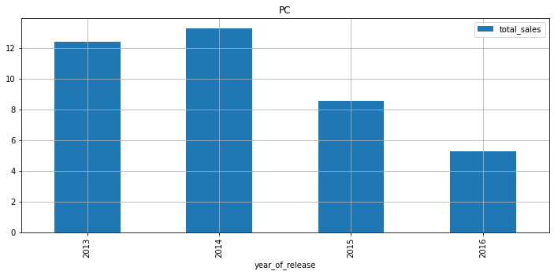

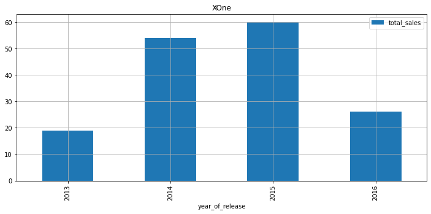

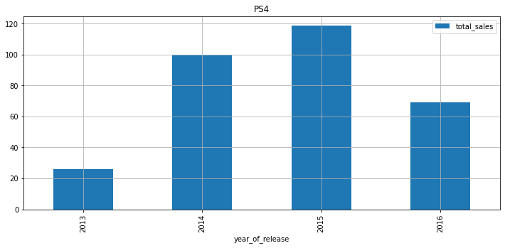

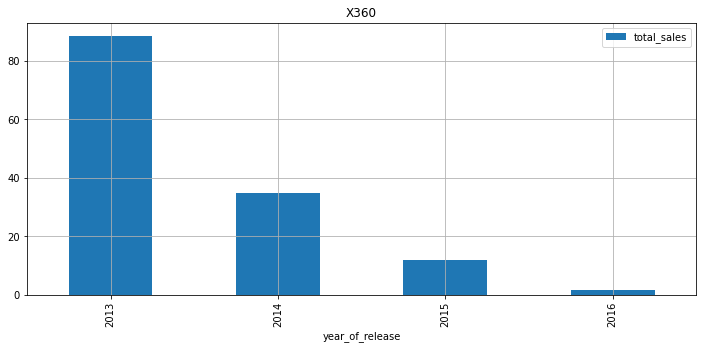

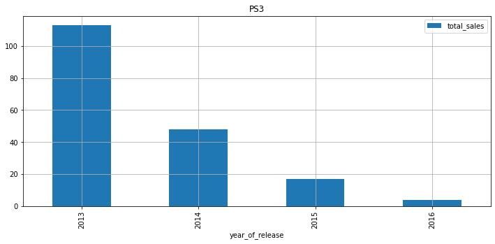

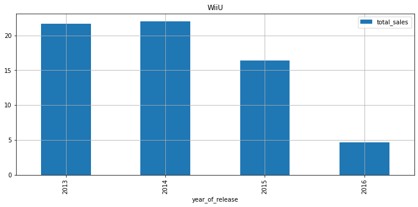

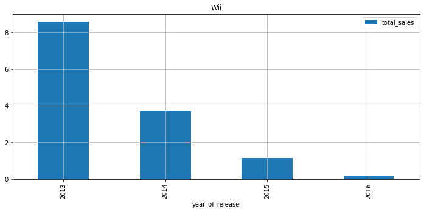

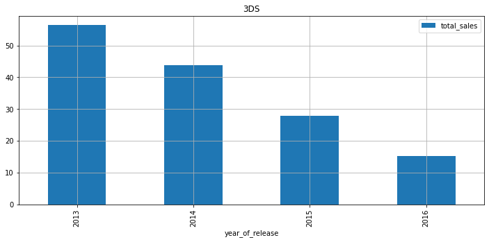

```python
for i in platform_actual:
    data_actual_cut.query('platform in @i').\
    pivot_table(index='year_of_release', values='total_sales', aggfunc='sum').\
    plot(kind='bar', title=i, grid=True, figsize=(12, 5));
```

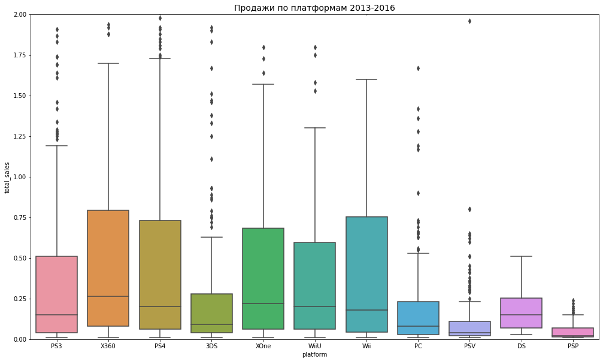

```python
plt.figure(figsize=(17,10))
sns.boxplot(x='platform', y='total_sales', data=data_period)
plt.title('Продажи по платформам 2013-2016', fontsize=14)
plt.axisbelow=True,  # Hide the grid behind plot objects
plt.xlabel='Платформы'
ylabel='Общие продажи'
plt.set_ylabel='Общие продажи'
labels=['Платформы']
plt.ylim(0, 2)
plt.show()
```

#### Влияние отзывов пользователей и критиков на продажи внутри платформы

```python
data_actual_cut_score = data_actual[['platform', 'genre', 'year_of_release', 'critic_score', 'user_score', 'total_sales']].sort_values(by='year_of_release')
data_actual_cut_score_critic = data_actual_cut_score.loc[data_actual_cut_score['critic_score'] != -1]
data_actual_cut_score_user = data_actual_cut_score.loc[data_actual_cut_score['user_score'] != -1]
```

##### Влияние оценок критиков на продажи

Построим диаграмму рассеяния

</font>**Комментарий студента. v2**  
Переделал

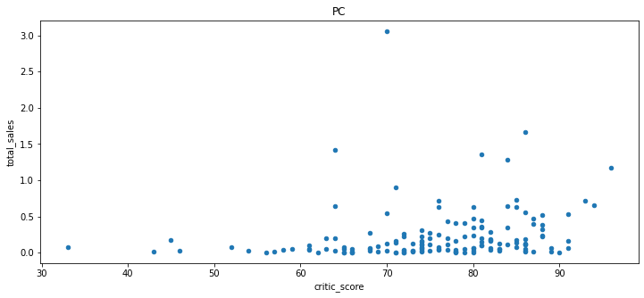

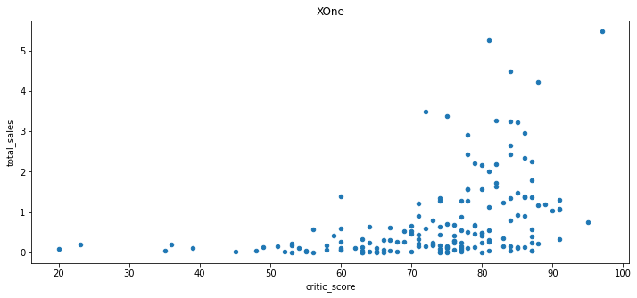

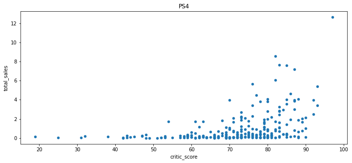

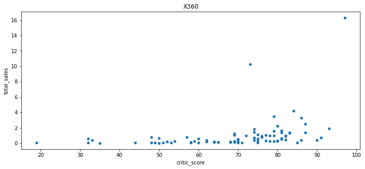

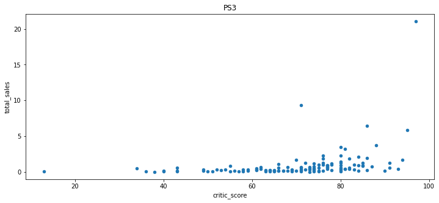

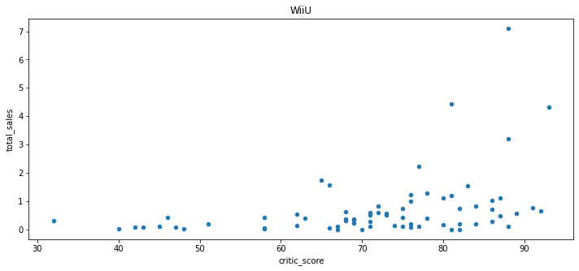

[figure not shown]

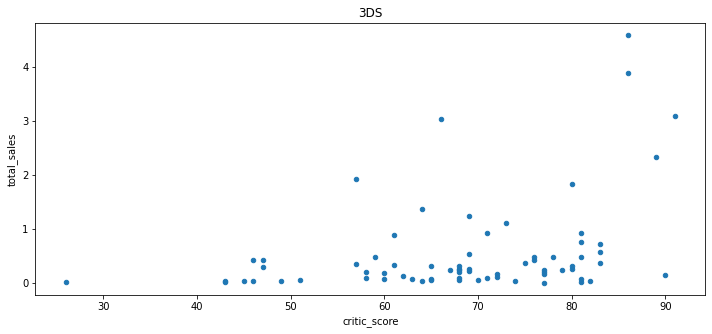

```python
for i in platform_actual:
    data_actual_cut_score_critic.query('platform == @i').\
    plot(x='critic_score', y='total_sales', kind='scatter', alpha=1, figsize=(12, 5), title=i);
```

Посчитаем корреляцию между отзывами и продажами

```python
for i in platform_actual:
    print('Корреляция critic_score и total_sales для', i, \
        data_actual_cut_score_critic.query('platform == @i')['critic_score'].\
        corr(data_actual_cut_score_critic.query('platform == @i')['total_sales']))
```

```
Корреляция critic_score и total_sales для PC 0.1960302829436937
Корреляция critic_score и total_sales для XOne 0.4169983280084017
Корреляция critic_score и total_sales для PS4 0.4065679020617809
Корреляция critic_score и total_sales для X360 0.35034454602286647
Корреляция critic_score и total_sales для PS3 0.33428533933719223
Корреляция critic_score и total_sales для WiiU 0.37641490654239124
Корреляция critic_score и total_sales для Wii nan
Корреляция critic_score и total_sales для 3DS 0.3570566142288106
```

Оценки критиков влияют на выбор пользователей.  
Между количеством продаж и отзывами критиков есть взамосвязь  
Странное что-то с Wii